# Strategy in a month-long prisoner's dilemma

## Overview

What strategies do players develop when they play a [10-round prisoner's dilemma game](https://en.wikipedia.org/wiki/Prisoner%27s_dilemma#The_iterated_prisoner.27s_dilemma) 20 times a day over the course of a month? First, let us imagine if you were one of the players. In each round, you and one other opponent **opp** can choose to cooperate **C** or defect **D** to receive the following payoffs:

|  | if opp chooses C | if opp chooses D |
| --- | --- | --- |
| **if you choose C** | you receive R | you receive S |
| **if you choose D** | you receive T | you receive P |

You also pay attention to what your opponent receives each round:

|  | if opp chooses C | if opp chooses D |
| --- | --- | --- |
| **if you choose C** | opp receives R | opp receives T |
| **if you choose D** | opp receives S | opp receives P |

You might wonder, what are **R**, **S**, **T**, and **P**? The paper we take our data from - [Mao et al. 2017](http://www.nature.com/articles/ncomms13800) - uses the following **RSTP** values:

|  | if opp chooses C | if opp chooses D |
| --- | --- | --- |
| **if you choose C** | you receive 5 points | you receive 1 points |
| **if you choose D** | you receive 7 points | you receive 3 points |

Points might seem abstract, but the stakes involve real money: for every 2 points a player receives in the game, he earns 1 cent afterwards. This means:

- If you have no strategy and play randomly and your opponent does the same, you might earn an average of 4 points a round, or 4 dollars a day. You might spend an average of 1 minute a game, or 20 minutes a day. At the end of the experiment you can walk away with 80 dollars at about 12 dollars an hour.
- If you have an excellent strategy and completely avoid ever receiving the lowest outcome **S** on any round, you might earn an average of 5 points a round, or 5 dollars a day. At the end of the experiment you can walk away with 100 dollars at about 15 dollars an hour.
- If you have a terrible strategy and never manage to receive the highest outcome **T** on any round, you might earn an average of 3 points a round, or 3 dollars a day. At the end of the experiment you can walk away with 60 dollars at about 9 dollars an hour.

Let us assume this is enough incentive for players to try and maximize their payoff in the game to some reasonable extent. Notice that:

- There is a temptation **T** to defect while your opponent cooperates, as this gives a larger payoff for you than the reward **R** for both players cooperating.
- But the reward **R** for both players cooperating is larger than the punishment **P** for both players defecting, so there is also a motivation to cooperate.
- But cooperating while your opponent defects gives the least payoff overall, so there is a motivation to avoid being suckered **S**.
- In addition, in terms of balance, the reward **R** is larger than the average of being suckered **S** and tempted **T**.

Altogether, this looks like:

$$T>R>P>S$$

and $$R>\frac{S+T}{2}$$

## Strategies

So what are the strategies that players might develop to maximize their payoff? We can get some idea of what to expect by looking at [Axelrod's tournaments](https://en.wikipedia.org/wiki/The_Evolution_of_Cooperation#Axelrod.27s_tournaments). In these tournaments, Axelrod invited game theorists to submit strategies to compete against one another. In the end, the successful strategies tried to:

- Be nice: Cooperate first and do not defect before your opponent.
- Retaliate: Do not continue to cooperate if your opponent defects.
- Forgive: Be open to cooperating again if your opponent does not continue to defect.
- Do not be greedy: Do not try to score more than your immediate opponent, only try to maximize your own score over the whole tournament.

In the games we are about to look at, the players will not be familiar with the success of these strategies. And unlike pre-programmed strategies, they could become emotional and make different choices than above. An aggresive player, for example, might reason as follows:

- Be nice? No! I can cooperate at first, but I will also defect first to avoid being suckered.
- Retaliate? Sure! I should not let my opponent walk all over me.
- Forgive? No! I should continue to retaliate, my opponent has betrayed my trust.
- Do not be greedy? No! I should always try to get the better of my opponent.

With this in mind, let us look at the games and see the strategies of successful players on the last day of play (Day 20). There are about 90 players playing 20 ten-round games over the course of the day.

## Pre-processing

First we need to:

- Remove incomplete games, namely games that do not have 20 actions (2 players acting over the course of 10 rounds)
- Divide the large dataset into the individual days

```
import numpy as np
import pandas as pd
```

```
actions = pd.read_csv('actions.csv')
players = actions['player'].unique()
gameids = actions['gameId'].unique()
games = actions['game'].unique()
```

```
for i in games:
    newactions = pd.DataFrame(actions[actions['day'] == i])
    newgameids = newactions['gameId'].unique()
    for j in range(len(newgameids)):
        if len(newactions[newactions['gameId'] == newgameids[j]]) != 20:
            newactions.drop(newactions.loc[newactions['gameId'] == newgameids[j]].index, inplace=True)
    newactions.to_csv('actions_complete_day%s.csv'%i)
```

## Payoff versus category

To find the strategies players use to maximize their payoff, we need to find players with the highest payoffs at the end of the day. To narrow down their strategy, we will look at how their actions have been categorized by **RSTP** outcomes.

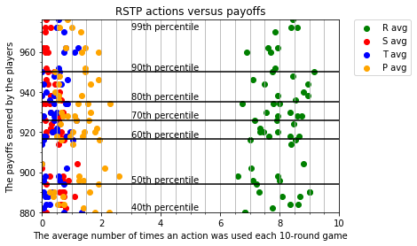

```python
import numpy as np
import pandas as pd

actions = pd.read_csv('actions_complete_day20.csv')
players = actions['player'].unique()
gameids = actions['gameId'].unique()
games = actions['game'].unique()

payoffs = np.zeros((players.shape[0],1))
categoryR = np.zeros((players.shape[0],1))
categoryS = np.zeros((players.shape[0],1))
categoryT = np.zeros((players.shape[0],1))
categoryP = np.zeros((players.shape[0],1))
for i in range(len(players)):
    payoffs[i] = actions[actions['player'] == players[i]]['payoff'].sum()
    categorytmp = actions[actions['player'] == players[i]]['payoff'].value_counts()
    if 5 in categorytmp.index:
        categoryR[i] = categorytmp[5]
    if 1 in categorytmp.index:
        categoryS[i] = categorytmp[1]
    if 7 in categorytmp.index:
        categoryT[i] = categorytmp[7]
    if 3 in categorytmp.index:
        categoryP[i] = categorytmp[3]

players = np.expand_dims(players, axis=1)

payvcat = np.concatenate((players, payoffs, categoryR, categoryS, categoryT, categoryP), axis=1)
payvcat = pd.DataFrame(payvcat)
payvcat.columns = ['player', 'payoff', 'R', 'S', 'T', 'P']

payvcat['num_actions'] = payvcat['R'] + payvcat['S'] + payvcat['T'] + payvcat['P']
payvcat['payoff_avg'] = payvcat['payoff']/(payvcat['num_actions']/10)
payvcat['R_avg'] = payvcat['R']/(payvcat['num_actions']/10)
payvcat['S_avg'] = payvcat['S']/(payvcat['num_actions']/10)
payvcat['T_avg'] = payvcat['T']/(payvcat['num_actions']/10)
payvcat['P_avg'] = payvcat['P']/(payvcat['num_actions']/10)

import matplotlib.pyplot as plt
plt.axhline(y=np.percentile(payvcat['payoff'],90), color='black', linestyle='-')
plt.text(3,np.percentile(payvcat['payoff'],90)+1,'90th percentile')
plt.axhline(y=np.percentile(payvcat['payoff'],80), color='black', linestyle='-')
plt.text(3,np.percentile(payvcat['payoff'],80)+1,'80th percentile')
plt.axhline(y=np.percentile(payvcat['payoff'],70), color='black', linestyle='-')
plt.text(3,np.percentile(payvcat['payoff'],70)+1,'70th percentile')
plt.axhline(y=np.percentile(payvcat['payoff'],60), color='black', linestyle='-')
plt.text(3,np.percentile(payvcat['payoff'],60)+1,'60th percentile')
plt.axhline(y=np.percentile(payvcat['payoff'],50), color='black', linestyle='-')
plt.text(3,np.percentile(payvcat['payoff'],50)+1,'50th percentile')
plt.scatter(payvcat['R_avg'], payvcat['payoff'], color='green', label='R avg')
plt.scatter(payvcat['S_avg'], payvcat['payoff'], color='red', label='S avg')
plt.scatter(payvcat['T_avg'], payvcat['payoff'], color='blue', label='T avg')
plt.scatter(payvcat['P_avg'], payvcat['payoff'], color='orange', label='P avg')
plt.axis([0, 10, np.percentile(payvcat['payoff'],40), np.percentile(payvcat['payoff'],100)])
plt.text(3,np.percentile(payvcat['payoff'],99)-1,'99th percentile')
plt.text(3,np.percentile(payvcat['payoff'],40)+1,'40th percentile')
plt.grid(b='on', which='both', axis='x')
plt.minorticks_on()
plt.xlabel('The average number of times an action was used each 10-round game')
plt.ylabel('The payoffs earned by the players')
plt.title('RSTP actions versus payoffs')
plt.legend(bbox_to_anchor=(1.05, 1), loc=2, borderaxespad=0.)
plt.show()
```

Looks like for each game, many of the more successful players often cooperate with their opponent for 8 rounds **R**, defect while the opponent continues to cooperate **T** for one round, and defect again while the opponent moves to defect **P** for another round, and generally avoid being suckered **S** in any round. That being said, there is quite a spread of successful strategies, and players above the 90th percentile are cooperating with their opponent anywhere between 7 to 8.5 times on average.

Although we are not yet looking at how players play round-by-round, at this point we can make hypothesis for how the most successful players strategize (Axelrod identified strategies are in blue and any violations are in red):

- (Round 1-8): Start off the round by cooperating ('Be nice')
- (Round 9): Defect while the opponent cooperates ('Not being nice')
- (Round 10): Defect while the opponent defects ('Retaliate')

But what about 'Forgive'? Here Axelrod's ideas might be less applicable. In Axelrod's tournaments, each strategy plays against another strategy for 200 rounds each game. In the games we are looking at, each player plays against another player for 10 rounds each game. This does not seem to be enough time to 'Forgive' since most defections start near the end of each game. Also, being consistently suckered even just once a game is enough to drop you to the bottom of our list while defecting before the opponent defects every game puts you at the top of our list. There just is not the same flexibility to 'Forgive' as in Axelrod's tournaments, where being suckered a couple times at the end of 200 rounds has much less weight than being suckered at the end of 10 rounds.

But what about 'Don't be greedy'? If the sole focus is to never score worse than your current opponent, the strategy would be to defect immediately: you will never do worse than your opponent and you will never be suckered, but your scores will always be the lowest at the end of the day. The highest-scoring strategy is opening to cooperating and thus open to scoring lower than the immediate opponent, but minimizes the risk of being suckered by correctly assuming most opponents will not defect earlier than it anticipates.

With this in mind, let us look at how several hypothetical strategies might play out:

Both players always cooperate

| Player | Round 1 | Round 2 | Round 3 | Round 4 | Round 5 | Round 6 | Round 7 | Round 8 | Round 9 | Round 10 | Payoff |
| --- | --- | --- | --- | --- | --- | --- | --- | --- | --- | --- | --- |
| you | R | R | R | R | R | R | R | R | R | R | 50 |
| opp | R | R | R | R | R | R | R | R | R | R | 50 |

You defect first on Round 10 (from now on we will assume your opponent will be suckered once then defect afterwards)

| Player | Round 1 | Round 2 | Round 3 | Round 4 | Round 5 | Round 6 | Round 7 | Round 8 | Round 9 | Round 10 | Payoff |
| --- | --- | --- | --- | --- | --- | --- | --- | --- | --- | --- | --- |
| you | R | R | R | R | R | R | R | R | R | T | 52 |
| opp | R | R | R | R | R | R | R | R | R | S | 46 |

You defect first on Round 9

| Player | Round 1 | Round 2 | Round 3 | Round 4 | Round 5 | Round 6 | Round 7 | Round 8 | Round 9 | Round 10 | Payoff |
| --- | --- | --- | --- | --- | --- | --- | --- | --- | --- | --- | --- |
| you | R | R | R | R | R | R | R | R | T | P | 50 |
| opp | R | R | R | R | R | R | R | R | S | P | 44 |

You defect first on Round 8

| Player | Round 1 | Round 2 | Round 3 | Round 4 | Round 5 | Round 6 | Round 7 | Round 8 | Round 9 | Round 10 | Payoff |
| --- | --- | --- | --- | --- | --- | --- | --- | --- | --- | --- | --- |
| you | R | R | R | R | R | R | R | T | P | P | 48 |
| opp | R | R | R | R | R | R | R | S | P | P | 42 |

A pattern emerges. You will earn 50 points for cooperating all 10 rounds or for defecting on Round 9. You will earn 2 points on top of the 50 if you defect on Round 10. But for each round of defections earlier than Round 9 you will lose 2 points from 50. For example, we can already see defecting on Round 8 will net you 48 points, or 2 less points than 50. Defecting that early consistently does not seem optimal unless enough other players have taken to similar strategies, so we will not consider these strategies unless the data warrants.

## In-game strategy

We have looked at a lot of hypothetical strategies in the previous section. Let us check the games to see if these guesses hold water. We want to see for sure what round-by-round strategies players use on Day 20 and see if we can start to model this human behavior.

First let us see how much of each player's behavior can be explained by the cases we proposed above. We want to first see what strategies players have planned, which will be more obvious if we look at actions categorized by **CD**. For example, if you plan to defect on Round 9 your **CD** action will always be consistent no matter if your opponent also defects or if your opponent cooperates at first.

```python
strategiesCD = pd.DataFrame(np.zeros((payvcat['player'].shape[0],20), dtype=object))
for i in range(len(payvcat['player'])):
    for j in range(20):
        strategiesCD[j][i] = np.array2string(actions[(actions['player'] == payvcat.loc[payvcat['player'].index[i]]['player'])
                                   & (actions['game'] == j+1)]['action'].values)

strategiesCDhypo = pd.DataFrame(np.zeros((len(strategiesCD),12), dtype=object))
for i in range(len(strategiesCD)):
    if '[1 1 1 1 1 1 1 1 1 1]' in strategiesCD.loc[i].value_counts():
        strategiesCDhypo[0][i] = '[1 1 1 1 1 1 1 1 1 1]'
        strategiesCDhypo[1][i] = strategiesCD.loc[i].value_counts()['[1 1 1 1 1 1 1 1 1 1]']
        strategiesCDhypo[2][i] = strategiesCD.loc[i].value_counts()['[1 1 1 1 1 1 1 1 1 1]']/(payvcat['num_actions'][i]/10)
    if '[1 1 1 1 1 1 1 1 1 0]' in strategiesCD.loc[i].value_counts():
        strategiesCDhypo[3][i] = '[1 1 1 1 1 1 1 1 1 0]'
        strategiesCDhypo[4][i] = strategiesCD.loc[i].value_counts()['[1 1 1 1 1 1 1 1 1 0]']
        strategiesCDhypo[5][i] = strategiesCD.loc[i].value_counts()['[1 1 1 1 1 1 1 1 1 0]']/(payvcat['num_actions'][i]/10)
    if '[1 1 1 1 1 1 1 1 0 0]' in strategiesCD.loc[i].value_counts():
        strategiesCDhypo[6][i] = '[1 1 1 1 1 1 1 1 0 0]'
        strategiesCDhypo[7][i] = strategiesCD.loc[i].value_counts()['[1 1 1 1 1 1 1 1 0 0]']
        strategiesCDhypo[8][i] = strategiesCD.loc[i].value_counts()['[1 1 1 1 1 1 1 1 0 0]']/(payvcat['num_actions'][i]/10)
    if '[1 1 1 1 1 1 1 0 0 0]' in strategiesCD.loc[i].value_counts():
        strategiesCDhypo[9][i] = '[1 1 1 1 1 1 1 0 0 0]'
        strategiesCDhypo[10][i] = strategiesCD.loc[i].value_counts()['[1 1 1 1 1 1 1 0 0 0]']
        strategiesCDhypo[11][i] = strategiesCD.loc[i].value_counts()['[1 1 1 1 1 1 1 0 0 0]']/(payvcat['num_actions'][i]/10)
strategiesCDhypo.columns = ['strat1', 'used1', 'freq1','strat2', 'used2', 'freq2','strat3', 'used3', 'freq3', 'strat4', 'used4', 'freq4']

ingamestrathypoCD = strategiesCDhypo
ingamestrathypoCD['player'] = payvcat['player']
ingamestrathypoCD['payoff'] = payvcat['payoff']
ingamestrathypoCD['num_actions'] = payvcat['num_actions']
ingamestrathypoCD['totalused'] = ingamestrathypoCD['used1'] + ingamestrathypoCD['used2'] + ingamestrathypoCD['used3'] + ingamestrathypoCD['used4']
ingamestrathypoCD['totalfreq'] = ingamestrathypoCD['freq1'] + ingamestrathypoCD['freq2'] + ingamestrathypoCD['freq3'] + ingamestrathypoCD['freq4']
ingamestrathypoCD.sort_values('payoff', ascending=False).head(n=10)
```

|  | strat1 | used1 | freq1 | strat2 | used2 | freq2 | strat3 | used3 | freq3 | strat4 | used4 | freq4 | player | payoff | num_actions | totalused | totalfreq |
| --- | --- | --- | --- | --- | --- | --- | --- | --- | --- | --- | --- | --- | --- | --- | --- | --- | --- |
| 63 | [1 1 1 1 1 1 1 1 1 1] | 1 | 0.05 | [1 1 1 1 1 1 1 1 1 0] | 10 | 0.5 | [1 1 1 1 1 1 1 1 0 0] | 9 | 0.45 | 0 | 0 | 0 | Mn8Mhh4DdiW724yZ3 | 976 | 200 | 20 | 1 |
| 49 | [1 1 1 1 1 1 1 1 1 1] | 4 | 0.2 | [1 1 1 1 1 1 1 1 1 0] | 5 | 0.25 | [1 1 1 1 1 1 1 1 0 0] | 8 | 0.4 | [1 1 1 1 1 1 1 0 0 0] | 3 | 0.15 | GwfkQ6SGEuBj2RMoW | 972 | 200 | 20 | 1 |
| 76 | [1 1 1 1 1 1 1 1 1 1] | 2 | 0.1 | [1 1 1 1 1 1 1 1 1 0] | 14 | 0.7 | [1 1 1 1 1 1 1 1 0 0] | 4 | 0.2 | 0 | 0 | 0 | Qi3GiWFco4Qh355LQ | 972 | 200 | 20 | 1 |
| 13 | 0 | 0 | 0 | [1 1 1 1 1 1 1 1 1 0] | 1 | 0.05 | [1 1 1 1 1 1 1 1 0 0] | 17 | 0.85 | [1 1 1 1 1 1 1 0 0 0] | 2 | 0.1 | C3pmKynLhdJMGdwf9 | 970 | 200 | 20 | 1 |
| 66 | 0 | 0 | 0 | 0 | 0 | 0 | [1 1 1 1 1 1 1 1 0 0] | 16 | 0.8 | [1 1 1 1 1 1 1 0 0 0] | 3 | 0.15 | 9oMznuhqogksvbTty | 962 | 200 | 19 | 0.95 |
| 78 | 0 | 0 | 0 | 0 | 0 | 0 | [1 1 1 1 1 1 1 1 0 0] | 19 | 1 | 0 | 0 | 0 | 97traC2z3p5PZ27XX | 962 | 190 | 19 | 1 |
| 67 | 0 | 0 | 0 | [1 1 1 1 1 1 1 1 1 0] | 1 | 0.05 | [1 1 1 1 1 1 1 1 0 0] | 16 | 0.8 | [1 1 1 1 1 1 1 0 0 0] | 3 | 0.15 | 7SuwNkTzDH5sA5JDC | 960 | 200 | 20 | 1 |
| 74 | 0 | 0 | 0 | [1 1 1 1 1 1 1 1 1 0] | 1 | 0.05 | [1 1 1 1 1 1 1 1 0 0] | 3 | 0.15 | [1 1 1 1 1 1 1 0 0 0] | 15 | 0.75 | kHR5CKiiL9FYWGwqn | 960 | 200 | 19 | 0.95 |
| 22 | [1 1 1 1 1 1 1 1 1 1] | 1 | 0.05 | [1 1 1 1 1 1 1 1 1 0] | 2 | 0.1 | [1 1 1 1 1 1 1 1 0 0] | 16 | 0.8 | 0 | 0 | 0 | t5q8PtjTJ5tBCCA48 | 952 | 200 | 19 | 0.95 |
| 58 | 0 | 0 | 0 | [1 1 1 1 1 1 1 1 1 0] | 1 | 0.05 | [1 1 1 1 1 1 1 1 0 0] | 18 | 0.9 | 0 | 0 | 0 | oEdzXdEbM6o7wyYF5 | 950 | 200 | 19 | 0.95 |

For the most part it seems our guesses explain the strategies used by top players (we will also look at the frequencies they employ each strategy later), but there are a few players later on that elude categorization. What could their strategies be?

```python
strategiesCDmain = pd.DataFrame(np.zeros((len(strategiesCD),15), dtype=object))
for i in range(len(strategiesCD)):
    strategiesCDmain[0][i] = strategiesCD.loc[i].value_counts().index[0]
    strategiesCDmain[1][i] = strategiesCD.loc[i].value_counts()[0]
    strategiesCDmain[2][i] = strategiesCD.loc[i].value_counts()[0]/(payvcat['num_actions'][i]/10)
    if len(strategiesCD.loc[i].value_counts()) > 1:
        strategiesCDmain[3][i] = strategiesCD.loc[i].value_counts().index[1]
        strategiesCDmain[4][i] = strategiesCD.loc[i].value_counts()[1]
        strategiesCDmain[5][i] = strategiesCD.loc[i].value_counts()[1]/(payvcat['num_actions'][i]/10)
    if len(strategiesCD.loc[i].value_counts()) > 2:
        strategiesCDmain[6][i] = strategiesCD.loc[i].value_counts().index[2]
        strategiesCDmain[7][i] = strategiesCD.loc[i].value_counts()[2]
        strategiesCDmain[8][i] = strategiesCD.loc[i].value_counts()[2]/(payvcat['num_actions'][i]/10)
    if len(strategiesCD.loc[i].value_counts()) > 3:
        strategiesCDmain[9][i] = strategiesCD.loc[i].value_counts().index[3]
        strategiesCDmain[10][i] = strategiesCD.loc[i].value_counts()[3]
        strategiesCDmain[11][i] = strategiesCD.loc[i].value_counts()[3]/(payvcat['num_actions'][i]/10)
    if len(strategiesCD.loc[i].value_counts()) > 4:
        strategiesCDmain[9][i] = strategiesCD.loc[i].value_counts().index[4]
        strategiesCDmain[10][i] = strategiesCD.loc[i].value_counts()[4]
        strategiesCDmain[11][i] = strategiesCD.loc[i].value_counts()[4]/(payvcat['num_actions'][i]/10)
strategiesCDmain.columns = ['strat1', 'used1', 'freq1','strat2', 'used2', 'freq2','strat3', 'used3', 'freq3','strat4', 'used4', 'freq4','strat5', 'used5', 'freq5']

ingamestratCD = strategiesCDmain
ingamestratCD['player'] = payvcat['player']
ingamestratCD['payoff'] = payvcat['payoff']
ingamestratCD['num_actions'] = payvcat['num_actions']
ingamestratCD['totalfreq'] = ingamestrathypoCD['totalfreq']
ingamestratCD.sort_values('payoff', ascending=False).head(n=10)
```

|  | strat1 | used1 | freq1 | strat2 | used2 | freq2 | strat3 | used3 | freq3 | strat4 | used4 | freq4 | strat5 | used5 | freq5 | player | payoff | num_actions | totalfreq |
| --- | --- | --- | --- | --- | --- | --- | --- | --- | --- | --- | --- | --- | --- | --- | --- | --- | --- | --- | --- |
| 63 | [1 1 1 1 1 1 1 1 1 0] | 10 | 0.5 | [1 1 1 1 1 1 1 1 0 0] | 9 | 0.45 | [1 1 1 1 1 1 1 1 1 1] | 1 | 0.05 | 0 | 0 | 0 | 0 | 0 | 0 | Mn8Mhh4DdiW724yZ3 | 976 | 200 | 1 |
| 49 | [1 1 1 1 1 1 1 1 0 0] | 8 | 0.4 | [1 1 1 1 1 1 1 1 1 0] | 5 | 0.25 | [1 1 1 1 1 1 1 1 1 1] | 4 | 0.2 | [1 1 1 1 1 1 1 0 0 0] | 3 | 0.15 | 0 | 0 | 0 | GwfkQ6SGEuBj2RMoW | 972 | 200 | 1 |
| 76 | [1 1 1 1 1 1 1 1 1 0] | 14 | 0.7 | [1 1 1 1 1 1 1 1 0 0] | 4 | 0.2 | [1 1 1 1 1 1 1 1 1 1] | 2 | 0.1 | 0 | 0 | 0 | 0 | 0 | 0 | Qi3GiWFco4Qh355LQ | 972 | 200 | 1 |
| 13 | [1 1 1 1 1 1 1 1 0 0] | 17 | 0.85 | [1 1 1 1 1 1 1 0 0 0] | 2 | 0.1 | [1 1 1 1 1 1 1 1 1 0] | 1 | 0.05 | 0 | 0 | 0 | 0 | 0 | 0 | C3pmKynLhdJMGdwf9 | 970 | 200 | 1 |
| 66 | [1 1 1 1 1 1 1 1 0 0] | 16 | 0.8 | [1 1 1 1 1 1 1 0 0 0] | 3 | 0.15 | [1 1 1 1 1 1 0 0 0 0] | 1 | 0.05 | 0 | 0 | 0 | 0 | 0 | 0 | 9oMznuhqogksvbTty | 962 | 200 | 0.95 |
| 78 | [1 1 1 1 1 1 1 1 0 0] | 19 | 1 | [] | 1 | 0.0526316 | 0 | 0 | 0 | 0 | 0 | 0 | 0 | 0 | 0 | 97traC2z3p5PZ27XX | 962 | 190 | 1 |
| 67 | [1 1 1 1 1 1 1 1 0 0] | 16 | 0.8 | [1 1 1 1 1 1 1 0 0 0] | 3 | 0.15 | [1 1 1 1 1 1 1 1 1 0] | 1 | 0.05 | 0 | 0 | 0 | 0 | 0 | 0 | 7SuwNkTzDH5sA5JDC | 960 | 200 | 1 |
| 74 | [1 1 1 1 1 1 1 0 0 0] | 15 | 0.75 | [1 1 1 1 1 1 1 1 0 0] | 3 | 0.15 | [1 1 0 0 0 0 0 0 0 0] | 1 | 0.05 | [1 1 1 1 1 1 1 1 1 0] | 1 | 0.05 | 0 | 0 | 0 | kHR5CKiiL9FYWGwqn | 960 | 200 | 0.95 |
| 22 | [1 1 1 1 1 1 1 1 0 0] | 16 | 0.8 | [1 1 1 1 1 1 1 1 1 0] | 2 | 0.1 | [1 1 1 1 1 1 1 1 1 1] | 1 | 0.05 | [1 1 1 1 0 0 0 0 0 0] | 1 | 0.05 | 0 | 0 | 0 | t5q8PtjTJ5tBCCA48 | 952 | 200 | 0.95 |
| 58 | [1 1 1 1 1 1 1 1 0 0] | 18 | 0.9 | [1 1 1 1 1 1 0 0 0 0] | 1 | 0.05 | [1 1 1 1 1 1 1 1 1 0] | 1 | 0.05 | 0 | 0 | 0 | 0 | 0 | 0 | oEdzXdEbM6o7wyYF5 | 950 | 200 | 0.95 |

Interestingly, we might be seeing the following strategies (again we will look at frequencies later):

You defect all 10 rounds:

| Player | Round 1 | Round 2 | Round 3 | Round 4 | Round 5 | Round 6 | Round 7 | Round 8 | Round 9 | Round 10 | Payoff |
| --- | --- | --- | --- | --- | --- | --- | --- | --- | --- | --- | --- |
| you | T | P | P | P | P | P | P | P | P | P | 34 |
| opp | S | P | P | P | P | P | P | P | P | P | 28 |

You defect first earlier than Round 8 (see our previous analysis). For example, you defect first on Round 7:

| Player | Round 1 | Round 2 | Round 3 | Round 4 | Round 5 | Round 6 | Round 7 | Round 8 | Round 9 | Round 10 | Payoff |
| --- | --- | --- | --- | --- | --- | --- | --- | --- | --- | --- | --- |
| you | R | R | R | R | R | R | T | P | P | P | 46 |
| opp | R | R | R | R | R | R | S | P | P | P | 40 |

You play "honorably":

| Player | Round 1 | Round 2 | Round 3 | Round 4 | Round 5 | Round 6 | Round 7 | Round 8 | Round 9 | Round 10 | Payoff |
| --- | --- | --- | --- | --- | --- | --- | --- | --- | --- | --- | --- |
| you | R | R | R | R | R | R | R | R | T | S | 48 |
| opp | R | R | R | R | R | R | R | R | S | T | 48 |

An interesting strategy where you guard against opponents who defect on Round 9 but if you end up defecting against an opponent that cooperates on Round 9, you cooperate on Round 10 to allow you and your opponent to score a respectable 48 points each. There is a variant where you guard on Round 8:

| Player | Round 1 | Round 2 | Round 3 | Round 4 | Round 5 | Round 6 | Round 7 | Round 8 | Round 9 | Round 10 | Payoff |
| --- | --- | --- | --- | --- | --- | --- | --- | --- | --- | --- | --- |
| you | R | R | R | R | R | R | R | T | S | P | 46 |
| opp | R | R | R | R | R | R | R | S | T | P | 46 |

You cooperate all 10 rounds. For example:

| Player | Round 1 | Round 2 | Round 3 | Round 4 | Round 5 | Round 6 | Round 7 | Round 8 | Round 9 | Round 10 | Payoff |
| --- | --- | --- | --- | --- | --- | --- | --- | --- | --- | --- | --- |
| you | R | R | R | R | R | R | R | R | S | S | 42 |
| opp | R | R | R | R | R | R | R | R | T | T | 54 |

Namely, you do not defect even when the opponent starts to defect.

Let us see if adding these strategies will explain the remaining players' strategies.

```python
strategiesCDhypo = pd.DataFrame(np.zeros((len(strategiesCD),42), dtype=object))
for i in range(len(strategiesCD)):
    if '[1 1 1 1 1 1 1 1 1 1]' in strategiesCD.loc[i].value_counts():
        strategiesCDhypo[0][i] = '[1 1 1 1 1 1 1 1 1 1]'
        strategiesCDhypo[1][i] = strategiesCD.loc[i].value_counts()['[1 1 1 1 1 1 1 1 1 1]']
        strategiesCDhypo[2][i] = strategiesCD.loc[i].value_counts()['[1 1 1 1 1 1 1 1 1 1]']/20
        #strategiesCDhypo[2][i] = strategiesCD.loc[i].value_counts()['[1 1 1 1 1 1 1 1 1 1]']/(payvcat['num_actions'][i]/10)
    if '[1 1 1 1 1 1 1 1 1 0]' in strategiesCD.loc[i].value_counts():
        strategiesCDhypo[3][i] = '[1 1 1 1 1 1 1 1 1 0]'
        strategiesCDhypo[4][i] = strategiesCD.loc[i].value_counts()['[1 1 1 1 1 1 1 1 1 0]']
        strategiesCDhypo[5][i] = strategiesCD.loc[i].value_counts()['[1 1 1 1 1 1 1 1 1 0]']/20
        #strategiesCDhypo[5][i] = strategiesCD.loc[i].value_counts()['[1 1 1 1 1 1 1 1 1 0]']/(payvcat['num_actions'][i]/10)
    if '[1 1 1 1 1 1 1 1 0 0]' in strategiesCD.loc[i].value_counts():
        strategiesCDhypo[6][i] = '[1 1 1 1 1 1 1 1 0 0]'
        strategiesCDhypo[7][i] = strategiesCD.loc[i].value_counts()['[1 1 1 1 1 1 1 1 0 0]']
        strategiesCDhypo[8][i] = strategiesCD.loc[i].value_counts()['[1 1 1 1 1 1 1 1 0 0]']/20
        #strategiesCDhypo[8][i] = strategiesCD.loc[i].value_counts()['[1 1 1 1 1 1 1 1 0 0]']/(payvcat['num_actions'][i]/10)
    if '[1 1 1 1 1 1 1 0 0 0]' in strategiesCD.loc[i].value_counts():
        strategiesCDhypo[9][i] = '[1 1 1 1 1 1 1 0 0 0]'
        strategiesCDhypo[10][i] = strategiesCD.loc[i].value_counts()['[1 1 1 1 1 1 1 0 0 0]']
        strategiesCDhypo[11][i] = strategiesCD.loc[i].value_counts()['[1 1 1 1 1 1 1 0 0 0]']/20
        #strategiesCDhypo[11][i] = strategiesCD.loc[i].value_counts()['[1 1 1 1 1 1 1 0 0 0]']/(payvcat['num_actions'][i]/10)
    if '[1 1 1 1 1 1 0 0 0 0]' in strategiesCD.loc[i].value_counts():
        strategiesCDhypo[12][i] = '[1 1 1 1 1 1 0 0 0 0]'
        strategiesCDhypo[13][i] = strategiesCD.loc[i].value_counts()['[1 1 1 1 1 1 0 0 0 0]']
        strategiesCDhypo[14][i] = strategiesCD.loc[i].value_counts()['[1 1 1 1 1 1 0 0 0 0]']/20
        #strategiesCDhypo[14][i] = strategiesCD.loc[i].value_counts()['[1 1 1 1 1 1 0 0 0 0]']/(payvcat['num_actions'][i]/10)
    if '[1 1 1 1 1 0 0 0 0 0]' in strategiesCD.loc[i].value_counts():
        strategiesCDhypo[15][i] = '[1 1 1 1 1 0 0 0 0 0]'
        strategiesCDhypo[16][i] = strategiesCD.loc[i].value_counts()['[1 1 1 1 1 0 0 0 0 0]']
        strategiesCDhypo[17][i] = strategiesCD.loc[i].value_counts()['[1 1 1 1 1 0 0 0 0 0]']/20
        #strategiesCDhypo[17][i] = strategiesCD.loc[i].value_counts()['[1 1 1 1 1 0 0 0 0 0]']/(payvcat['num_actions'][i]/10)
    if '[1 1 1 1 0 0 0 0 0 0]' in strategiesCD.loc[i].value_counts():
        strategiesCDhypo[18][i] = '[1 1 1 1 0 0 0 0 0 0]'
        strategiesCDhypo[19][i] = strategiesCD.loc[i].value_counts()['[1 1 1 1 0 0 0 0 0 0]']
        strategiesCDhypo[20][i] = strategiesCD.loc[i].value_counts()['[1 1 1 1 0 0 0 0 0 0]']/20
        #strategiesCDhypo[20][i] = strategiesCD.loc[i].value_counts()['[1 1 1 1 0 0 0 0 0 0]']/(payvcat['num_actions'][i]/10)
    if '[1 1 1 0 0 0 0 0 0 0]' in strategiesCD.loc[i].value_counts():
        strategiesCDhypo[21][i] = '[1 1 1 0 0 0 0 0 0 0]'
        strategiesCDhypo[22][i] = strategiesCD.loc[i].value_counts()['[1 1 1 0 0 0 0 0 0 0]']
        strategiesCDhypo[23][i] = strategiesCD.loc[i].value_counts()['[1 1 1 0 0 0 0 0 0 0]']/20
        #strategiesCDhypo[23][i] = strategiesCD.loc[i].value_counts()['[1 1 1 0 0 0 0 0 0 0]']/(payvcat['num_actions'][i]/10)
    if '[1 1 0 0 0 0 0 0 0 0]' in strategiesCD.loc[i].value_counts():
        strategiesCDhypo[24][i] = '[1 1 0 0 0 0 0 0 0 0]'
        strategiesCDhypo[25][i] = strategiesCD.loc[i].value_counts()['[1 1 0 0 0 0 0 0 0 0]']
        strategiesCDhypo[26][i] = strategiesCD.loc[i].value_counts()['[1 1 0 0 0 0 0 0 0 0]']/20
        #strategiesCDhypo[26][i] = strategiesCD.loc[i].value_counts()['[1 1 0 0 0 0 0 0 0 0]']/(payvcat['num_actions'][i]/10)
    if '[1 0 0 0 0 0 0 0 0 0]' in strategiesCD.loc[i].value_counts():
        strategiesCDhypo[27][i] = '[1 0 0 0 0 0 0 0 0 0]'
        strategiesCDhypo[28][i] = strategiesCD.loc[i].value_counts()['[1 0 0 0 0 0 0 0 0 0]']
        strategiesCDhypo[29][i] = strategiesCD.loc[i].value_counts()['[1 0 0 0 0 0 0 0 0 0]']/20
        #strategiesCDhypo[29][i] = strategiesCD.loc[i].value_counts()['[1 0 0 0 0 0 0 0 0 0]']/(payvcat['num_actions'][i]/10)
    if '[0 0 0 0 0 0 0 0 0 0]' in strategiesCD.loc[i].value_counts():
        strategiesCDhypo[30][i] = '[0 0 0 0 0 0 0 0 0 0]'
        strategiesCDhypo[31][i] = strategiesCD.loc[i].value_counts()['[0 0 0 0 0 0 0 0 0 0]']
        strategiesCDhypo[32][i] = strategiesCD.loc[i].value_counts()['[0 0 0 0 0 0 0 0 0 0]']/20
        #strategiesCDhypo[32][i] = strategiesCD.loc[i].value_counts()['[0 0 0 0 0 0 0 0 0 0]']/(payvcat['num_actions'][i]/10)
    if '[1 1 1 1 1 1 1 1 0 1]' in strategiesCD.loc[i].value_counts():
        strategiesCDhypo[33][i] = '[1 1 1 1 1 1 1 1 0 1]'
        strategiesCDhypo[34][i] = strategiesCD.loc[i].value_counts()['[1 1 1 1 1 1 1 1 0 1]']
        strategiesCDhypo[35][i] = strategiesCD.loc[i].value_counts()['[1 1 1 1 1 1 1 1 0 1]']/20
        #strategiesCDhypo[35][i] = strategiesCD.loc[i].value_counts()['[1 1 1 1 1 1 1 1 0 1]']/(payvcat['num_actions'][i]/10)
    if '[1 1 1 1 1 1 1 0 1 0]' in strategiesCD.loc[i].value_counts():
        strategiesCDhypo[36][i] = '[1 1 1 1 1 1 1 0 1 0]'
        strategiesCDhypo[37][i] = strategiesCD.loc[i].value_counts()['[1 1 1 1 1 1 1 0 1 0]']
        strategiesCDhypo[38][i] = strategiesCD.loc[i].value_counts()['[1 1 1 1 1 1 1 0 1 0]']/20
        #strategiesCDhypo[38][i] = strategiesCD.loc[i].value_counts()['[1 1 1 1 1 1 1 1 0 1]']/(payvcat['num_actions'][i]/10)
    if '[]' in strategiesCD.loc[i].value_counts():
        strategiesCDhypo[39][i] = '[]'
        strategiesCDhypo[40][i] = strategiesCD.loc[i].value_counts()['[]']
        strategiesCDhypo[41][i] = strategiesCD.loc[i].value_counts()['[]']/20
        #strategiesCDhypo[38][i] = strategiesCD.loc[i].value_counts()['[]']/(payvcat['num_actions'][i]/10)
strategiesCDhypo.columns = ['strat1', 'used1', 'freq1','strat2', 'used2', 'freq2','strat3', 'used3', 'freq3', 'strat4', 'used4', 'freq4', 'strat5', 'used5', 'freq5', 'strat6', 'used6', 'freq6', 'strat7', 'used7', 'freq7', 'strat8', 'used8', 'freq8', 'strat9', 'used9', 'freq9', 'strat10', 'used10', 'freq10', 'strat11', 'used11', 'freq11', 'strat12', 'used12', 'freq12', 'strat13', 'used13', 'freq13', 'strat14', 'used14', 'freq14']

pd.set_option("display.max_columns",100)
ingamestrathypoCD = strategiesCDhypo
ingamestrathypoCD['player'] = payvcat['player']
ingamestrathypoCD['payoff'] = payvcat['payoff']
ingamestrathypoCD['num_actions'] = payvcat['num_actions']
ingamestrathypoCD['totalused'] = ingamestrathypoCD['used1'] + ingamestrathypoCD['used2'] + ingamestrathypoCD['used3'] + ingamestrathypoCD['used4'] + ingamestrathypoCD['used5'] + ingamestrathypoCD['used6'] + ingamestrathypoCD['used7'] + ingamestrathypoCD['used8'] + ingamestrathypoCD['used9'] + ingamestrathypoCD['used10'] + ingamestrathypoCD['used11'] + ingamestrathypoCD['used12'] + ingamestrathypoCD['used13'] + ingamestrathypoCD['used14']
ingamestrathypoCD['totalfreq'] = ingamestrathypoCD['freq1'] + ingamestrathypoCD['freq2'] + ingamestrathypoCD['freq3'] + ingamestrathypoCD['freq4'] + ingamestrathypoCD['freq5'] + ingamestrathypoCD['freq6'] + ingamestrathypoCD['freq7'] + ingamestrathypoCD['freq8'] + ingamestrathypoCD['freq9'] + ingamestrathypoCD['freq10'] + ingamestrathypoCD['freq11'] + ingamestrathypoCD['freq12'] + ingamestrathypoCD['freq13'] + ingamestrathypoCD['freq14']
ingamestrathypoCD.sort_values('payoff', ascending=False).head(n=10)
```

|  | strat1 | used1 | freq1 | strat2 | used2 | freq2 | strat3 | used3 | freq3 | strat4 | used4 | freq4 | strat5 | used5 | freq5 | strat6 | used6 | freq6 | strat7 | used7 | freq7 | strat8 | used8 | freq8 | strat9 | used9 | freq9 | strat10 | used10 | … |
| --- | --- | --- | --- | --- | --- | --- | --- | --- | --- | --- | --- | --- | --- | --- | --- | --- | --- | --- | --- | --- | --- | --- | --- | --- | --- | --- | --- | --- | --- | --- |
| 63 | [1 1 1 1 1 1 1 1 1 1] | 1 | 0.05 | [1 1 1 1 1 1 1 1 1 0] | 10 | 0.5 | [1 1 1 1 1 1 1 1 0 0] | 9 | 0.45 | 0 | 0 | 0 | 0 | 0 | 0 | 0 | 0 | 0 | 0 | 0 | 0 | 0 | 0 | 0 | 0 | 0 | 0 | 0 | 0 | … |
| 49 | [1 1 1 1 1 1 1 1 1 1] | 4 | 0.2 | [1 1 1 1 1 1 1 1 1 0] | 5 | 0.25 | [1 1 1 1 1 1 1 1 0 0] | 8 | 0.4 | [1 1 1 1 1 1 1 0 0 0] | 3 | 0.15 | 0 | 0 | 0 | 0 | 0 | 0 | 0 | 0 | 0 | 0 | 0 | 0 | 0 | 0 | 0 | 0 | 0 | … |
| 76 | [1 1 1 1 1 1 1 1 1 1] | 2 | 0.1 | [1 1 1 1 1 1 1 1 1 0] | 14 | 0.7 | [1 1 1 1 1 1 1 1 0 0] | 4 | 0.2 | 0 | 0 | 0 | 0 | 0 | 0 | 0 | 0 | 0 | 0 | 0 | 0 | 0 | 0 | 0 | 0 | 0 | 0 | 0 | 0 | … |
| 13 | 0 | 0 | 0 | [1 1 1 1 1 1 1 1 1 0] | 1 | 0.05 | [1 1 1 1 1 1 1 1 0 0] | 17 | 0.85 | [1 1 1 1 1 1 1 0 0 0] | 2 | 0.1 | 0 | 0 | 0 | 0 | 0 | 0 | 0 | 0 | 0 | 0 | 0 | 0 | 0 | 0 | 0 | 0 | 0 | … |
| 66 | 0 | 0 | 0 | 0 | 0 | 0 | [1 1 1 1 1 1 1 1 0 0] | 16 | 0.8 | [1 1 1 1 1 1 1 0 0 0] | 3 | 0.15 | [1 1 1 1 1 1 0 0 0 0] | 1 | 0.05 | 0 | 0 | 0 | 0 | 0 | 0 | 0 | 0 | 0 | 0 | 0 | 0 | 0 | 0 | … |
| 78 | 0 | 0 | 0 | 0 | 0 | 0 | [1 1 1 1 1 1 1 1 0 0] | 19 | 0.95 | 0 | 0 | 0 | 0 | 0 | 0 | 0 | 0 | 0 | 0 | 0 | 0 | 0 | 0 | 0 | 0 | 0 | 0 | 0 | 0 | … |
| 67 | 0 | 0 | 0 | [1 1 1 1 1 1 1 1 1 0] | 1 | 0.05 | [1 1 1 1 1 1 1 1 0 0] | 16 | 0.8 | [1 1 1 1 1 1 1 0 0 0] | 3 | 0.15 | 0 | 0 | 0 | 0 | 0 | 0 | 0 | 0 | 0 | 0 | 0 | 0 | 0 | 0 | 0 | 0 | 0 | … |
| 74 | 0 | 0 | 0 | [1 1 1 1 1 1 1 1 1 0] | 1 | 0.05 | [1 1 1 1 1 1 1 1 0 0] | 3 | 0.15 | [1 1 1 1 1 1 1 0 0 0] | 15 | 0.75 | 0 | 0 | 0 | 0 | 0 | 0 | 0 | 0 | 0 | 0 | 0 | 0 | [1 1 0 0 0 0 0 0 0 0] | 1 | 0.05 | 0 | 0 | … |
| 22 | [1 1 1 1 1 1 1 1 1 1] | 1 | 0.05 | [1 1 1 1 1 1 1 1 1 0] | 2 | 0.1 | [1 1 1 1 1 1 1 1 0 0] | 16 | 0.8 | 0 | 0 | 0 | 0 | 0 | 0 | 0 | 0 | 0 | [1 1 1 1 0 0 0 0 0 0] | 1 | 0.05 | 0 | 0 | 0 | 0 | 0 | 0 | 0 | 0 | … |
| 58 | 0 | 0 | 0 | [1 1 1 1 1 1 1 1 1 0] | 1 | 0.05 | [1 1 1 1 1 1 1 1 0 0] | 18 | 0.9 | 0 | 0 | 0 | [1 1 1 1 1 1 0 0 0 0] | 1 | 0.05 | 0 | 0 | 0 | 0 | 0 | 0 | 0 | 0 | 0 | 0 | 0 | 0 | 0 | 0 | … |

## Modeling behavior

More or less, a majority of strategies players use fall under the cases we outlined above. What is less clear is when players dictate strategy (for example, by defecting first), when players react to their opponent's strategy (for example, retaliating after the opponent defects first) and when players switch strategies (for example, switching to an earlier defection strategy after being suckered one too many times).

```python
strategiesRSTP = pd.DataFrame(np.zeros((payvcat['player'].shape[0],20), dtype=object))
for i in range(len(payvcat['player'])):
    for j in range(20):
        strategiesRSTP[j][i] = np.array2string(actions[(actions['player'] == payvcat.loc[payvcat['player'].index[i]]['player'])
                                   & (actions['game'] == j+1)]['payoff'].values)
```

```python
strategiesRSTP['payoff'] = payvcat['payoff']
strategiesRSTP.sort_values('payoff', ascending=False).head(n=10)
```

|  | 0 | 1 | 2 | 3 | 4 | 5 | 6 | 7 | 8 | 9 | 10 | 11 | 12 | 13 | 14 | 15 | 16 | 17 | 18 | 19 | payoff |
| --- | --- | --- | --- | --- | --- | --- | --- | --- | --- | --- | --- | --- | --- | --- | --- | --- | --- | --- | --- | --- | --- |
| 63 | [5 5 5 5 5 5 5 5 5 7] | [5 5 5 5 5 5 5 5 7 7] | [5 5 5 5 5 5 5 5 5 7] | [5 5 5 5 5 5 5 5 1 7] | [5 5 5 5 5 5 5 5 5 7] | [5 5 5 5 5 5 5 5 5 7] | [5 5 5 5 5 5 5 1 1 3] | [5 5 5 5 5 5 5 5 3 3] | [5 5 5 5 5 5 5 5 7 3] | [5 5 5 5 5 5 5 5 3 3] | [5 5 5 5 5 5 5 5 5 3] | [5 5 5 5 5 5 5 5 7 3] | [5 5 5 5 5 5 5 5 3 3] | [5 5 5 5 5 5 5 5 3 3] | [5 5 5 5 5 5 5 5 3 3] | [5 5 5 5 5 5 5 5 5 3] | [5 5 5 5 5 5 5 5 5 5] | [5 5 5 5 5 5 5 5 5 7] | [5 5 5 5 5 5 5 5 3 3] | [5 5 5 5 5 5 5 5 5 7] | 976 |
| 49 | [5 5 5 5 5 5 5 5 5 3] | [5 5 5 5 5 5 5 5 7 3] | [5 5 5 5 5 5 5 5 7 3] | [5 5 5 5 5 5 5 5 7 3] | [5 5 5 5 5 5 5 5 7 3] | [5 5 5 5 5 5 5 5 5 3] | [5 5 5 5 5 5 5 5 3 3] | [5 5 5 5 5 5 5 7 3 3] | [5 5 5 5 5 5 5 5 1 3] | [5 5 5 5 5 5 5 5 5 5] | [5 5 5 5 5 5 5 5 5 5] | [5 5 5 5 5 5 5 5 5 7] | [5 5 5 5 5 5 5 5 7 3] | [5 5 5 5 5 5 5 7 3 3] | [5 5 5 5 5 5 5 5 3 3] | [5 5 5 5 5 5 5 5 5 5] | [5 5 5 5 5 5 5 5 5 5] | [5 5 5 5 5 5 5 5 1 3] | [5 5 5 5 5 5 5 5 7 3] | [5 5 5 5 5 5 5 7 3 3] | 972 |
| 76 | [5 5 5 5 5 5 5 5 5 7] | [5 5 5 5 5 5 5 5 5 7] | [5 5 5 5 5 5 5 5 5 7] | [5 5 5 5 5 5 5 5 5 7] | [5 5 5 5 5 5 5 5 5 7] | [5 5 5 5 5 5 5 1 3 3] | [5 5 5 5 5 5 5 5 5 5] | [5 5 5 5 5 5 5 1 3 3] | [5 5 5 5 5 5 5 5 5 7] | [5 5 5 5 5 5 5 5 5 7] | [5 5 5 5 5 5 5 5 5 3] | [5 5 5 5 5 5 5 5 1 3] | [5 5 5 5 5 5 5 5 5 5] | [5 5 5 5 5 5 5 1 3 3] | [5 5 5 5 5 5 5 1 3 3] | [5 5 5 5 5 5 5 5 5 3] | [5 5 5 5 5 5 5 5 1 3] | [5 5 5 5 5 5 5 5 5 7] | [5 5 5 5 5 5 5 5 5 7] | [5 5 5 5 5 5 5 5 5 7] | 972 |
| 13 | [5 5 5 5 5 5 5 5 7 3] | [5 5 5 5 5 5 5 5 7 3] | [5 5 5 5 5 5 5 5 3 3] | [5 5 5 5 5 5 5 5 7 3] | [5 5 5 5 5 5 5 5 3 3] | [5 5 5 5 5 5 5 5 7 3] | [5 5 5 5 5 5 5 7 7 3] | [5 5 5 5 5 5 5 5 7 3] | [5 5 5 5 5 5 5 5 7 3] | [5 5 5 5 5 5 5 5 7 3] | [5 5 5 5 5 5 5 5 7 3] | [5 5 5 5 5 5 5 1 1 3] | [5 5 5 5 5 5 5 5 7 3] | [5 5 5 5 5 5 5 5 7 3] | [5 5 5 5 5 5 5 5 3 3] | [5 5 5 5 5 5 5 5 3 3] | [5 5 5 5 5 5 5 5 7 3] | [5 5 5 5 5 5 5 5 7 3] | [5 5 5 5 5 5 5 7 3 3] | [5 5 5 5 5 5 5 5 3 3] | 970 |
| 66 | [5 5 5 5 5 5 5 7 3 3] | [5 5 5 5 5 5 5 7 3 3] | [5 5 5 5 5 5 5 5 7 3] | [5 5 5 5 5 5 5 5 7 3] | [5 5 5 5 5 5 5 5 7 3] | [5 5 5 5 5 5 5 5 3 3] | [5 5 5 5 5 5 5 5 7 3] | [5 5 5 5 5 5 5 5 3 3] | [5 5 5 5 5 5 5 5 7 3] | [5 5 5 5 5 5 5 5 7 7] | [5 5 5 5 5 5 5 5 7 3] | [5 5 5 5 5 5 5 5 7 7] | [5 5 5 5 5 5 5 5 7 3] | [5 5 5 5 5 5 5 5 3 3] | [5 5 5 5 5 5 5 1 3 3] | [5 5 5 5 5 5 5 1 3 3] | [5 5 5 5 5 5 5 7 7 3] | [5 5 5 5 5 5 7 3 3 3] | [5 5 5 5 5 5 5 5 3 3] | [5 5 5 5 5 5 5 1 3 3] | 962 |
| 78 | [] | [5 5 5 5 5 5 5 5 7 3] | [5 5 5 5 5 5 5 5 3 3] | [5 5 5 5 5 5 5 5 7 7] | [5 5 5 5 5 5 5 5 7 7] | [5 5 5 5 5 5 5 5 7 7] | [5 5 5 5 5 5 5 5 3 3] | [5 5 5 5 5 5 5 5 7 3] | [5 5 5 5 5 5 5 5 7 7] | [5 5 5 5 5 5 5 5 7 3] | [5 5 5 5 5 5 5 5 3 3] | [5 5 5 5 5 5 5 5 7 3] | [5 5 5 5 5 5 5 5 7 7] | [5 5 5 5 5 5 5 5 7 3] | [5 5 5 5 5 5 5 5 7 7] | [5 5 5 5 5 5 5 5 7 3] | [5 5 5 5 5 5 5 5 7 3] | [5 5 5 5 5 5 5 1 3 3] | [5 5 5 5 5 5 5 5 7 7] | [5 5 5 5 5 5 5 5 7 7] | 962 |
| 67 | [5 5 5 5 5 5 5 1 3 3] | [5 5 5 5 5 5 5 5 7 3] | [5 5 5 5 5 5 5 5 3 3] | [5 5 5 5 5 5 5 5 7 7] | [5 5 5 5 5 5 5 1 7 3] | [5 5 5 5 5 5 5 5 7 3] | [5 5 5 5 5 5 5 5 7 3] | [5 5 5 5 5 5 5 1 3 3] | [5 5 5 5 5 5 5 7 3 3] | [5 5 5 5 5 5 5 7 3 3] | [5 5 5 5 5 5 5 7 3 3] | [5 5 5 5 5 5 5 5 7 3] | [5 5 5 5 5 5 5 5 7 3] | [5 5 5 5 5 5 5 5 7 7] | [5 5 5 5 5 5 5 5 5 3] | [5 5 5 5 5 5 5 5 3 3] | [5 5 5 5 5 5 5 5 7 3] | [5 5 5 5 5 5 5 1 3 3] | [5 5 5 5 5 5 5 5 3 3] | [5 5 5 5 5 5 5 5 7 3] | 960 |
| 74 | [5 5 5 5 5 5 5 5 7 3] | [5 5 5 5 5 5 5 7 3 3] | [5 5 5 5 5 5 5 7 3 3] | [5 5 5 5 5 5 5 7 3 3] | [1 1 3 3 3 3 3 3 3 3] | [5 5 5 5 5 5 5 7 3 3] | [5 5 5 5 5 5 5 7 3 3] | [5 5 5 5 5 5 5 5 3 3] | [5 5 5 5 5 5 5 7 3 3] | [5 5 5 5 5 5 5 7 7 7] | [5 5 5 5 5 5 5 7 3 3] | [5 5 5 5 5 5 5 7 3 3] | [5 5 5 5 5 5 5 5 7 3] | [5 5 5 5 5 5 5 7 3 3] | [5 5 5 5 5 5 5 7 3 3] | [5 5 5 5 5 5 5 7 3 3] | [5 5 5 5 5 5 5 7 3 3] | [5 5 5 5 5 5 5 7 3 3] | [5 5 5 5 5 5 5 7 7 7] | [5 5 5 5 5 5 5 5 5 7] | 960 |
| 22 | [5 5 5 5 5 5 5 5 5 1] | [5 5 5 5 5 5 5 5 7 3] | [5 5 5 5 5 5 5 5 5 7] | [5 5 5 5 5 5 5 5 3 3] | [5 5 5 5 5 5 5 5 7 3] | [5 5 5 5 5 5 5 5 3 3] | [5 5 5 5 5 5 5 5 7 3] | [5 5 5 5 5 5 5 5 7 3] | [5 5 5 5 5 5 5 5 3 3] | [5 5 5 5 5 5 5 5 7 3] | [5 5 5 5 5 5 5 5 7 3] | [5 5 5 5 5 5 5 5 7 3] | [5 5 5 5 5 5 5 5 3 3] | [5 5 5 5 5 5 5 5 3 3] | [5 5 5 5 5 5 5 5 3 3] | [5 5 1 1 3 3 3 3 3 3] | [5 5 5 5 5 5 5 5 5 7] | [5 5 5 5 5 5 5 5 3 3] | [5 5 5 5 5 5 5 5 7 3] | [5 5 5 5 5 5 5 5 7 3] | 952 |
| 58 | [5 5 5 5 5 5 5 5 7 3] | [5 5 5 5 5 5 7 3 3 3] | [5 5 5 5 5 5 5 5 7 3] | [5 5 5 5 5 5 5 5 3 7] | [5 5 5 5 5 5 5 5 7 3] | [5 5 5 5 5 5 5 1 3 3] | [5 5 5 5 5 5 5 5 7 3] | [5 5 5 5 5 5 5 5 3 3] | [5 5 5 5 5 5 5 5 3 3] | [5 5 5 5 5 5 5 5 7 3] | [5 5 5 5 5 5 5 5 3 3] | [5 5 5 5 5 5 5 1 1 3] | [5 5 5 5 5 5 5 5 3 3] | [5 5 5 5 5 5 5 1 3 3] | [5 5 5 5 5 5 5 5 7 3] | [5 5 5 5 5 5 5 5 7 3] | [5 5 5 5 5 5 5 5 7 3] | [5 5 5 5 5 5 5 5 7 3] | [5 5 5 5 5 5 5 5 3 3] | [5 5 5 5 5 5 5 5 7 3] | 950 |